# DiffuChannel: comparison of real and diffusion-generated single-channel records

Barrett-Jolley lab

07 August 2026

# Purpose

This notebook takes real (seed) patch-clamp records and DiffuChannel-generated records, computes every similarity metric reported in the manuscript, draws every figure, and writes a `results_values.csv` whose rows are keyed to the `[[placeholder]]` names used in the manuscript draft. Fill the manuscript from that file rather than from the console.

Nothing here assumes a particular result. If the model has not learned the noise structure, the plots will say so.

# Packages

```r
required <- c("dplyr", "tidyr", "ggplot2", "readr", "purrr", "arrow",
              "scales", "patchwork", "uwot", "Rtsne")

missing <- required[!vapply(required, requireNamespace, logical(1), quietly = TRUE)]
if (length(missing)) {
  message("Install these before running: ", paste(missing, collapse = ", "))
  message('install.packages(c("', paste(missing, collapse = '", "'), '"))')
}

library(dplyr)
library(tidyr)
library(ggplot2)
library(readr)
library(purrr)
library(arrow)
library(patchwork)

set.seed(42)
```

# Configuration

Everything you need to change lives in this block.

```r
CFG <- list(

  # ---- where the data are -------------------------------------------------
  real_dir       = "./pages",                       # folder of seed CSV / Parquet
  gen_file       = "./generated_dataset.parquet",   # cascade output
  gen_single_file = "./generated_single_stage.parquet", # ablation; NA if not run
  out_dir        = "./figures",

  # ---- recording parameters ----------------------------------------------
  sample_hz      = 1e4,     # acquisition rate, Hz. Must match SAMPLE_DT in diffusion_app.py
  filter_hz      = 1e3,     # anti-alias / Bessel corner frequency, Hz

  # ---- must match how the model was trained -------------------------------
  seq_len        = 128,     # training window, samples
  slow_factor    = 64,      # decimation factor of the coarse stage
  context_len    = 512,     # carried context at block joins
  block_len      = 32768,   # generation block length
  burst_tc       = 1000,    # BURST_TC in diffusion_app.py: flicker threshold, samples
  emb_dim        = 4,       # per-record embedding width used by the coarse stage
  emb_drop       = 0.1,     # embedding dropout during coarse training

  # ---- analysis knobs ------------------------------------------------------
  n_windows_mmd  = 400,     # windows per group for MMD. O(n^2): keep modest
  n_windows_proj = 600,     # windows per group for UMAP / t-SNE
  proj_win       = 512,     # window length for manifold projections
  psd_seg        = 1024,    # Welch segment length
  acf_lag_max    = 200,     # autocorrelation lag, samples
  ks_subsample   = 2e5,     # cap for KS tests (ks.test is slow on millions)

  # ---- plotting ------------------------------------------------------------
  trace_secs     = 0.5,     # duration of example traces to plot
  base_size      = 10
)

dir.create(CFG$out_dir, showWarnings = FALSE, recursive = TRUE)

# Results are collected here and written out at the end.
RESULTS <- new.env(parent = emptyenv())
RESULTS$rows <- list()

record_value <- function(key, value, note = "") {
  RESULTS$rows[[key]] <- tibble::tibble(
    placeholder = key,
    value       = if (is.numeric(value)) format(value, digits = 4) else as.character(value),
    note        = note
  )
  invisible(value)
}
```

# Theme

A plain publication theme. No decoration that a reviewer will ask you to remove.

```r
theme_channel <- function(base_size = CFG$base_size) {
  theme_classic(base_size = base_size) +
    theme(
      strip.background = element_blank(),
      strip.text       = element_text(face = "bold", hjust = 0),
      legend.position  = "top",
      legend.title     = element_blank(),
      legend.key.size  = unit(0.8, "lines"),
      plot.title       = element_text(face = "bold", size = base_size + 1),
      axis.text        = element_text(colour = "black")
    )
}

pal_source <- c(
  "Real"          = "#1b1b1b",
  "Generated"     = "#c0392b",
  "Single-stage"  = "#2980b9",
  "White noise"   = "#7f8c8d"
)

save_fig <- function(plot, name, width = 7, height = 4.2) {
  ggsave(file.path(CFG$out_dir, paste0(name, ".pdf")), plot,
         width = width, height = height)
  ggsave(file.path(CFG$out_dir, paste0(name, ".png")), plot,
         width = width, height = height, dpi = 300)
  invisible(plot)
}
```

# Helper functions

## Reading records

Handles both the tidy column names and whatever the acquisition software produced.

```r
normalise_names <- function(nms) {
  gsub("[_-]", " ", trimws(tolower(nms)))
}

read_record <- function(path) {
  df <- if (grepl("\\.parquet$", path, ignore.case = TRUE)) {
    as.data.frame(arrow::read_parquet(path))
  } else {
    as.data.frame(readr::read_csv(path, show_col_types = FALSE))
  }

  nn  <- normalise_names(names(df))
  idx <- function(target) {
    hit <- which(nn %in% target)
    if (length(hit)) hit[1] else NA_integer_
  }

  i_chan <- idx(c("channels", "channel", "ideal", "idealisation", "idealization"))
  i_cur  <- idx(c("noisy current", "current", "raw", "raw current", "i"))
  i_time <- idx(c("time", "t"))

  if (is.na(i_chan) || is.na(i_cur)) {
    stop("Could not find Channels / Noisy Current columns in ", basename(path),
         ". Found: ", paste(names(df), collapse = ", "))
  }

  out <- tibble::tibble(
    channels = as.numeric(df[[i_chan]]),
    current  = as.numeric(df[[i_cur]])
  )
  out$time <- if (!is.na(i_time)) as.numeric(df[[i_time]]) else
    (seq_len(nrow(out)) - 1) / CFG$sample_hz

  out |>
    dplyr::filter(is.finite(channels), is.finite(current)) |>
    dplyr::select(time, channels, current)
}

# Sample rate taken from the file's own Time column rather than from CFG. The
# app's export "Decimation factor" multiplies the Time step, so a generated
# file can sit at a different rate from the seed data, and PSD, ACF and dwell
# times are all silently wrong if that goes unnoticed.
fs_of <- function(d, fallback = CFG$sample_hz) {
  if (nrow(d) < 3) return(fallback)
  dt <- stats::median(diff(d$time), na.rm = TRUE)
  if (!is.finite(dt) || dt <= 0) return(fallback)
  1 / dt
}

read_folder <- function(dir) {
  files <- c(
    list.files(dir, pattern = "\\.csv$",     full.names = TRUE),
    list.files(dir, pattern = "\\.parquet$", full.names = TRUE)
  ) |> sort()

  if (!length(files)) stop("No CSV or Parquet files found in ", dir)

  purrr::map(files, ~ dplyr::mutate(read_record(.x), record = basename(.x)))
}
```

## Windowing and MMD

```r
make_windows <- function(x, win, n_max = Inf, stride = NULL) {
  n <- length(x)
  if (n < win) return(matrix(numeric(0), nrow = 0, ncol = win))
  if (is.null(stride)) {
    stride <- max(1L, floor((n - win) / max(1L, min(n_max, n))))
  }
  starts <- seq(1L, n - win + 1L, by = stride)
  if (length(starts) > n_max) starts <- sample(starts, n_max)
  t(vapply(starts, function(s) x[s:(s + win - 1L)], numeric(win)))
}

sq_dists <- function(A, B) {
  aa <- rowSums(A^2)
  bb <- rowSums(B^2)
  d  <- outer(aa, bb, "+") - 2 * tcrossprod(A, B)
  pmax(d, 0)
}

# Bandwidth by the median heuristic: gamma = 1 / median pairwise squared
# distance, so that a typical pair sits where the kernel actually varies.
# This matters more than it sounds. The fixed gamma = 1/L used in
# diffusion_103.py is right for standardised windows but far too narrow for
# current in pA: on a record with a 7 pA standard deviation, gamma * median(d2)
# comes out around 100, every kernel evaluation underflows to zero, and the
# statistic collapses onto its finite-sample floor of 1/m + 1/n regardless of
# what the two samples actually contain.
median_gamma <- function(X, Y, n_sub = 200) {
  A <- X[sample(nrow(X), min(n_sub, nrow(X))), , drop = FALSE]
  B <- Y[sample(nrow(Y), min(n_sub, nrow(Y))), , drop = FALSE]
  m <- stats::median(sq_dists(A, B))
  if (!is.finite(m) || m <= 0) 1 / ncol(X) else 1 / m
}

# unbiased = TRUE drops the i == j diagonal (the U-statistic). The diagonal
# terms are all exactly 1 and contribute (1/m + 1/n) of pure bias to the
# V-statistic, which is what puts a floor under the biased version.
mmd_rbf <- function(X, Y, gamma = NULL, unbiased = TRUE) {
  m <- nrow(X); n <- nrow(Y)
  if (m < 2 || n < 2) return(NA_real_)
  if (is.null(gamma)) gamma <- median_gamma(X, Y)

  Kxx <- exp(-gamma * sq_dists(X, X))
  Kyy <- exp(-gamma * sq_dists(Y, Y))
  Kxy <- exp(-gamma * sq_dists(X, Y))

  if (unbiased) {
    (sum(Kxx) - sum(diag(Kxx))) / (m * (m - 1)) +
      (sum(Kyy) - sum(diag(Kyy))) / (n * (n - 1)) -
      2 * mean(Kxy)
  } else {
    mean(Kxx) + mean(Kyy) - 2 * mean(Kxy)
  }
}

# Permutation test: pool the two sets, reshuffle the labels, and see where the
# observed statistic falls in the null it generates. This answers the question
# the raw number cannot -- given that two draws from one stochastic process are
# never identical, is this difference larger than relabelling would produce?
mmd_permutation_p <- function(X, Y, n_perm = 200, gamma = NULL) {
  if (is.null(gamma)) gamma <- median_gamma(X, Y)
  obs <- mmd_rbf(X, Y, gamma)
  Z <- rbind(X, Y); m <- nrow(X)
  null <- replicate(n_perm, {
    i <- sample(nrow(Z))
    mmd_rbf(Z[i[seq_len(m)], , drop = FALSE],
            Z[i[-seq_len(m)], , drop = FALSE], gamma)
  })
  list(mmd = obs, p = (1 + sum(null >= obs)) / (n_perm + 1),
       null_mean = mean(null), null_sd = sd(null), gamma = gamma)
}
```

## Welch power spectral density

Written out rather than pulled from a package, so that the estimate is transparent and the notebook has one fewer dependency.

```r
welch_psd <- function(x, fs, nperseg = 1024, noverlap = NULL, detrend = TRUE) {
  x <- as.numeric(x[is.finite(x)])
  if (length(x) < nperseg) return(NULL)
  if (is.null(noverlap)) noverlap <- nperseg %/% 2

  step   <- nperseg - noverlap
  starts <- seq(1L, length(x) - nperseg + 1L, by = step)
  w      <- 0.5 - 0.5 * cos(2 * pi * (seq_len(nperseg) - 1) / (nperseg - 1))  # Hann
  U      <- sum(w^2)

  acc <- numeric(nperseg %/% 2 + 1)
  for (s in starts) {
    seg <- x[s:(s + nperseg - 1L)]
    if (detrend) seg <- seg - mean(seg)
    X <- stats::fft(seg * w)[seq_len(nperseg %/% 2 + 1)]
    acc <- acc + (Mod(X)^2) / (fs * U)
  }
  psd <- acc / length(starts)
  psd[-c(1, length(psd))] <- 2 * psd[-c(1, length(psd))]  # one-sided

  tibble::tibble(
    freq = seq(0, fs / 2, length.out = length(psd)),
    psd  = psd
  ) |> dplyr::filter(freq > 0)
}
```

## Dwell times and a simple idealiser

```r
dwell_times <- function(ideal, fs) {
  r <- rle(as.integer(round(ideal)))
  tibble::tibble(
    level    = r$values,
    n_sample = r$lengths,
    dwell_ms = 1000 * r$lengths / fs
  ) |>
    dplyr::filter(n_sample > 0) |>
    dplyr::mutate(state = ifelse(level == 0, "Closed", "Open"))
}

# Half-amplitude threshold idealiser. Levels are estimated from the amplitude
# histogram of the closed baseline and the mode of the open population.
# The original mad()-based amplitude estimate is fragile on a strongly bimodal
# record: if it fails it returns all-NA, and rle() then reports one "dwell" per
# sample, which is what silently destroyed the ground-truth check on the first
# run. Levels are now taken from the two largest peaks of the amplitude density,
# which is what an experimenter reads off the all-points histogram anyway, and
# the baseline is taken from the closed population rather than the global median.
idealise_half_amplitude <- function(current, unit_pA = NULL, baseline = NULL,
                                    n_levels = 1) {
  d <- density(current, n = 4096)

  # Local maxima of the density, strongest first.
  is_peak <- c(FALSE, diff(sign(diff(d$y))) == -2, FALSE)
  pk <- data.frame(x = d$x[is_peak], y = d$y[is_peak])
  pk <- pk[order(-pk$y), , drop = FALSE]

  if (is.null(baseline)) baseline <- if (nrow(pk)) pk$x[1] else median(current)

  if (is.null(unit_pA)) {
    # The open level is the strongest peak that is not the baseline peak.
    far <- pk[abs(pk$x - baseline) > 0.5 * sd(current), , drop = FALSE]
    unit_pA <- if (nrow(far)) far$x[1] - baseline else NA_real_
  }

  if (!is.finite(unit_pA) || abs(unit_pA) < .Machine$double.eps^0.5) {
    warning("Could not estimate the unitary amplitude from the density. ",
            "Pass unit_pA (and baseline) explicitly: read them off Figure 2E.")
    return(rep(NA_integer_, length(current)))
  }

  lvl <- (current - baseline) / unit_pA
  pmin(pmax(as.integer(round(lvl)), 0L), as.integer(n_levels))
}

block_mean <- function(x, factor) {
  factor <- max(1L, as.integer(factor))
  nb <- length(x) %/% factor
  if (nb < 1) return(mean(x))
  colMeans(matrix(x[seq_len(nb * factor)], nrow = factor))
}
```

## Subsampled KS test

```r
ks_safe <- function(a, b, n_max = CFG$ks_subsample) {
  a <- a[is.finite(a)]; b <- b[is.finite(b)]
  if (length(a) > n_max) a <- sample(a, n_max)
  if (length(b) > n_max) b <- sample(b, n_max)
  suppressWarnings(stats::ks.test(a, b))
}
```

# 1. Load the data

```r
real_list <- read_folder(CFG$real_dir)
real      <- dplyr::bind_rows(real_list)

gen <- read_record(CFG$gen_file)
gen$record <- "generated"

has_single <- !is.na(CFG$gen_single_file) && file.exists(CFG$gen_single_file)
gen_single <- if (has_single) {
  x <- read_record(CFG$gen_single_file); x$record <- "single-stage"; x
} else {
  message("No single-stage file found. Ablation sections will be skipped.")
  NULL
}

FS_REAL <- fs_of(real_list[[1]])
FS_GEN  <- fs_of(gen)
FS_SING <- if (has_single) fs_of(gen_single) else NA_real_

cat(sprintf("Sample rate  real %.1f Hz | generated %.1f Hz\n", FS_REAL, FS_GEN))
```

```
## Sample rate  real 20000.0 Hz | generated 10000.0 Hz
```

```r
cat(sprintf("Real:      %d record(s), %s samples (%.1f s)\n",
            length(real_list), format(nrow(real), big.mark = ","),
            nrow(real) / FS_REAL))
```

```
## Real:      1 record(s), 824,001 samples (41.2 s)
```

```r
cat(sprintf("Generated: %s samples (%.1f s)\n",
            format(nrow(gen), big.mark = ","), nrow(gen) / FS_GEN))
```

```
## Generated: 100,000 samples (10.0 s)
```

```r
if (abs(FS_REAL - FS_GEN) / FS_REAL > 0.01) {
  warning(sprintf(paste("Real and generated sample rates differ (%.1f vs %.1f Hz).",
                        "Almost certainly the export Decimation factor was > 1.",
                        "Per-file rates are used throughout, but a generated record",
                        "coarser than the seed data cannot reproduce its high-frequency",
                        "noise and the PSD comparison will be truncated."),
                  FS_REAL, FS_GEN))
}

record_value("n_records",  length(real_list), "seed records")
record_value("n_samples",  format(nrow(real), big.mark = ","), "total seed samples")
record_value("n_seconds",  round(nrow(real) / FS_REAL, 1), "seconds of seed data")
record_value("sample_khz", FS_REAL / 1000)
record_value("filter_khz", CFG$filter_hz / 1000)
record_value("seq_len",    CFG$seq_len)
record_value("slow_factor", CFG$slow_factor)
record_value("context_len", CFG$context_len)
record_value("block_len",   CFG$block_len)
record_value("burst_tc",    CFG$burst_tc, "flicker threshold for the burst clock")
record_value("emb_dim",     CFG$emb_dim)
record_value("emb_drop",    CFG$emb_drop)
record_value("seq_len_ms",  round(1000 * CFG$seq_len / FS_REAL, 2),
             "training window duration")
record_value("long_len_s",  round(nrow(gen) / FS_GEN, 1))
record_value("n_blocks",    max(1, ceiling(nrow(gen) /
                              (CFG$block_len - CFG$context_len))))
```

## Table 1: seed data summary

```r
table1 <- purrr::map_dfr(real_list, function(d) {
  tibble::tibble(
    Record       = d$record[1],
    Samples      = nrow(d),
    `Duration (s)` = round(nrow(d) / FS_REAL, 2),
    `Max levels` = max(d$channels, na.rm = TRUE),
    `Open prob.` = round(mean(d$channels > 0), 4),
    `Mean (pA)`  = round(mean(d$current), 3),
    `SD (pA)`    = round(sd(d$current), 3)
  )
})

knitr::kable(table1, caption = "Table 1. Seed records used for training and evaluation.")
```

Table 1. Seed records used for training and evaluation.

| Record | Samples | Duration (s) | Max levels | Open prob. | Mean (pA) | SD (pA) |
| --- | --- | --- | --- | --- | --- | --- |
| claire_03560xoriginqubnoise1_SamFormat.csv | 824001 | 41.2 | 1 | 0.3654 | 13.695 | 7.141 |

```r
readr::write_csv(table1, file.path(CFG$out_dir, "table1_seed_data.csv"))
```

# 2. Figure 2: traces and amplitude distribution

## 2B–D: example traces

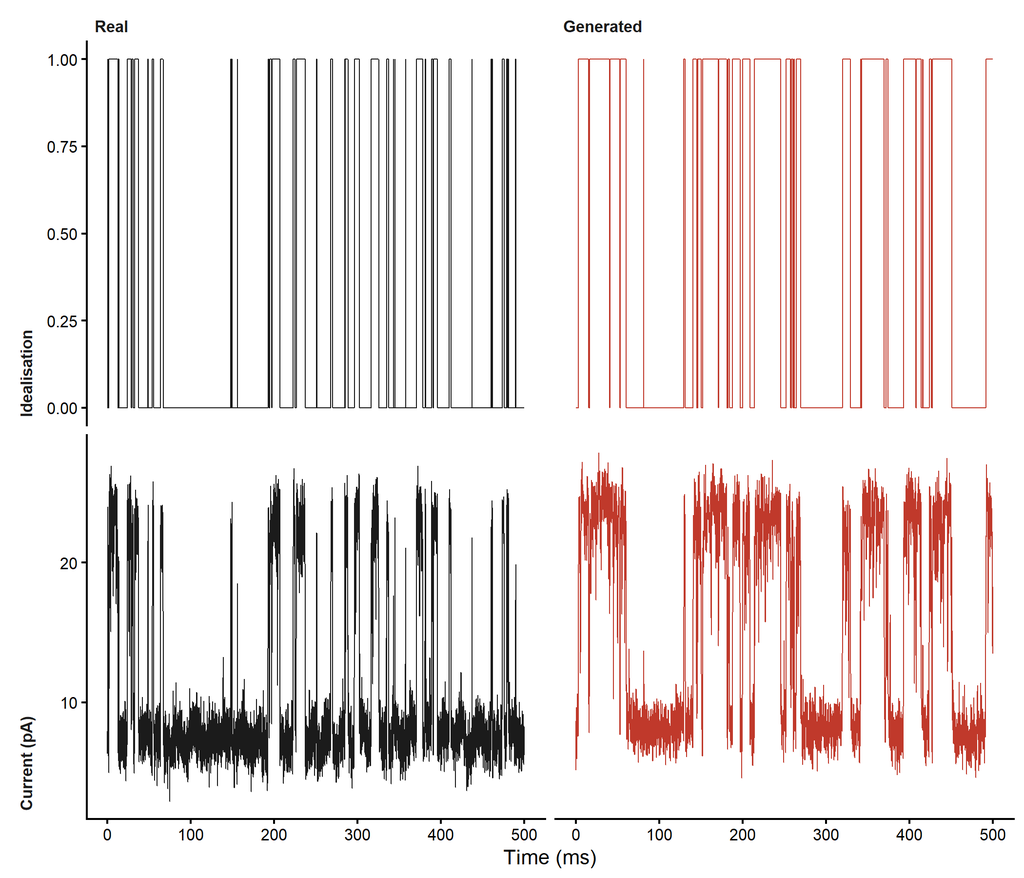

```r
n_show_real <- round(CFG$trace_secs * FS_REAL)
n_show_gen  <- round(CFG$trace_secs * FS_GEN)

trace_df <- dplyr::bind_rows(
  real |> dplyr::slice_head(n = n_show_real) |>
    dplyr::select(time, channels, current) |> dplyr::mutate(source = "Real"),
  gen  |> dplyr::slice_head(n = n_show_gen) |>
    dplyr::select(time, channels, current) |> dplyr::mutate(source = "Generated")
) |>
  dplyr::mutate(
    time_ms = 1000 * (time - min(time)),
    source  = factor(source, levels = c("Real", "Generated"))
  ) |>
  tidyr::pivot_longer(c(channels, current), names_to = "signal", values_to = "value") |>
  dplyr::mutate(signal = factor(
    signal, levels = c("channels", "current"),
    labels = c("Idealisation", "Current (pA)")
  ))

p_traces <- ggplot(trace_df, aes(time_ms, value, colour = source)) +
  geom_line(linewidth = 0.25) +
  facet_grid(signal ~ source, scales = "free_y", switch = "y") +
  scale_colour_manual(values = pal_source, guide = "none") +
  labs(x = "Time (ms)", y = NULL) +
  theme_channel() +
  theme(strip.placement = "outside")

p_traces
```

```r
save_fig(p_traces, "fig2_traces", height = 5)
```

## 2E: all-points amplitude histograms

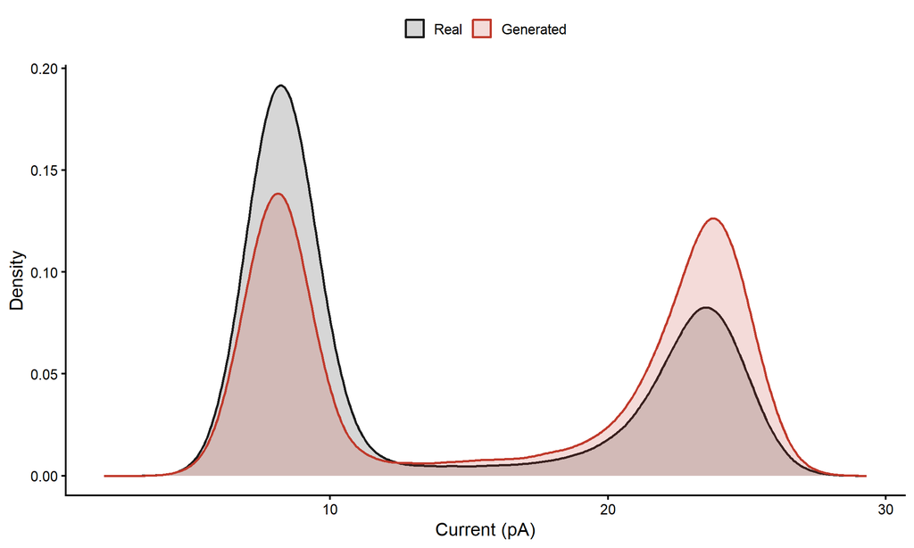

```r
amp_df <- dplyr::bind_rows(
  tibble::tibble(current = real$current, source = "Real"),
  tibble::tibble(current = gen$current,  source = "Generated")
) |>
  dplyr::mutate(source = factor(source, levels = c("Real", "Generated")))

p_amp <- ggplot(amp_df, aes(current, colour = source, fill = source)) +
  geom_density(alpha = 0.18, linewidth = 0.6, adjust = 0.6) +
  scale_colour_manual(values = pal_source) +
  scale_fill_manual(values = pal_source) +
  labs(x = "Current (pA)", y = "Density") +
  theme_channel()

p_amp
```

```r
save_fig(p_amp, "fig2E_amplitude_histogram")

# Modes and dispersion
mode_of <- function(x) { d <- density(x, n = 4096); d$x[which.max(d$y)] }

closed_real <- real$current[real$channels == 0]
closed_gen  <- gen$current[gen$channels == 0]

record_value("modes_real", round(mode_of(real$current), 3), "modal current, real, pA")
record_value("modes_gen",  round(mode_of(gen$current), 3),  "modal current, generated, pA")
record_value("sd_real",    round(sd(closed_real), 4), "closed-state SD, real, pA")
record_value("sd_gen",     round(sd(closed_gen), 4),  "closed-state SD, generated, pA")

ks_amp <- ks_safe(real$current, gen$current)
record_value("ks_D", round(unname(ks_amp$statistic), 4),
             "KS statistic, all-points amplitude, real vs generated")
ks_amp
```

```
##
##  Asymptotic two-sample Kolmogorov-Smirnov test
##
## data:  a and b
## D = 0.1857, p-value < 2.2e-16
## alternative hypothesis: two-sided
```

# 3. Maximum mean discrepancy

Three numbers, and the first is meaningless without the other two. The within-real value is the floor from finite sampling; the white-noise value is what a naive noise model scores.

```r
W_real <- make_windows(real$current, CFG$seq_len, CFG$n_windows_mmd)
W_gen  <- make_windows(gen$current,  CFG$seq_len, CFG$n_windows_mmd)

half   <- floor(nrow(real) / 2)
W_r1   <- make_windows(real$current[1:half],              CFG$seq_len, CFG$n_windows_mmd)
W_r2   <- make_windows(real$current[(half + 1):nrow(real)], CFG$seq_len, CFG$n_windows_mmd)

white  <- rnorm(nrow(real), mean(real$current), sd(real$current))
W_white <- make_windows(white, CFG$seq_len, CFG$n_windows_mmd)

# All three share one bandwidth, taken from the real-vs-generated comparison,
# so the numbers can be read against each other.
g0 <- median_gamma(W_real, W_gen)
mmd_main        <- mmd_rbf(W_real, W_gen,   gamma = g0)
mmd_within_real <- mmd_rbf(W_r1,   W_r2,    gamma = g0)
mmd_white       <- mmd_rbf(W_real, W_white, gamma = g0)

mmd_tbl <- tibble::tibble(
  Comparison = c("Real vs generated", "Real vs real (split half)",
                 "Real vs Gaussian white noise"),
  MMD        = c(mmd_main, mmd_within_real, mmd_white)
)

if (has_single) {
  W_gs <- make_windows(gen_single$current, CFG$seq_len, CFG$n_windows_mmd)
  mmd_tbl <- dplyr::bind_rows(
    mmd_tbl,
    tibble::tibble(Comparison = "Real vs single-stage", MMD = mmd_rbf(W_real, W_gs, gamma = g0))
  )
}

# One bandwidth for every comparison, or the numbers are not on one scale.
GAMMA <- median_gamma(W_real, W_gen)
cat(sprintf("Median-heuristic gamma = %.3e (fixed 1/L would be %.3e)\n",
            GAMMA, 1 / CFG$seq_len))
```

```
## Median-heuristic gamma = 7.025e-05 (fixed 1/L would be 7.812e-03)
```

```r
mmd_tbl$`MMD (gamma = 1/L, biased)` <- c(
  mmd_rbf(W_real, W_gen,  gamma = 1 / CFG$seq_len, unbiased = FALSE),
  mmd_rbf(W_r1,   W_r2,   gamma = 1 / CFG$seq_len, unbiased = FALSE),
  mmd_rbf(W_real, W_white, gamma = 1 / CFG$seq_len, unbiased = FALSE)
)[seq_len(nrow(mmd_tbl))]

knitr::kable(mmd_tbl, digits = 6,
             caption = paste("Maximum mean discrepancy. The first column uses",
                             "the median-heuristic bandwidth and the unbiased",
                             "estimator; the second reproduces the fixed 1/L",
                             "biased version printed during training."))
```

Maximum mean discrepancy. The first column uses the median-heuristic bandwidth and the unbiased estimator; the second reproduces the fixed 1/L biased version printed during training.

| Comparison | MMD | MMD (gamma = 1/L, biased) |
| --- | --- | --- |
| Real vs generated | 0.045882 | 0.006371 |
| Real vs real (split half) | 0.004824 | 0.007015 |
| Real vs Gaussian white noise | 0.072120 | 0.013169 |

```r
perm <- mmd_permutation_p(W_real, W_gen, n_perm = 200, gamma = GAMMA)
cat(sprintf(paste("\nPermutation test, real vs generated: MMD = %.5f,",
                  "null mean %.5f (SD %.5f), p = %.3f\n"),
            perm$mmd, perm$null_mean, perm$null_sd, perm$p))
```

```
##
## Permutation test, real vs generated: MMD = 0.04627, null mean -0.00017 (SD 0.00178), p = 0.005
```

```r
record_value("mmd_perm_p", signif(perm$p, 3),
             "permutation p, real vs generated windows")
record_value("mmd_gamma", signif(GAMMA, 4), "median-heuristic kernel bandwidth")

record_value("mmd_main",        signif(mmd_main, 4))
record_value("mmd_within_real", signif(mmd_within_real, 4))
record_value("mmd_white",       signif(mmd_white, 4))
```

# 4. Figure 3: noise structure

## 3A: power spectral density of the closed state

Computed on closed-state segments only, so gating does not contaminate the estimate. This is the plot that tells you whether the model learned the recording noise or just its variance.

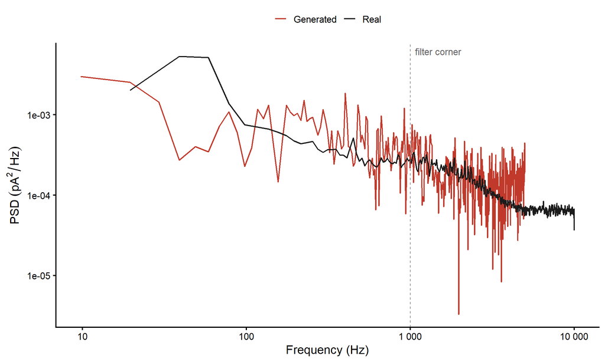

```r
longest_closed_run <- function(d, min_len) {
  r <- rle(d$channels == 0)
  ends <- cumsum(r$lengths)
  starts <- ends - r$lengths + 1
  keep <- which(r$values & r$lengths >= min_len)
  if (!length(keep)) return(numeric(0))
  unlist(lapply(keep, function(i) d$current[starts[i]:ends[i]]))
}

closed_real_seg <- longest_closed_run(real, CFG$psd_seg)
closed_gen_seg  <- longest_closed_run(gen,  CFG$psd_seg)

psd_labelled <- function(x, label, fs) {
  p <- welch_psd(x, fs, CFG$psd_seg)
  if (is.null(p)) {
    warning("Not enough closed-state samples for a PSD estimate: ", label,
            ". Lower CFG$psd_seg or use a record with longer closed periods.")
    return(NULL)
  }
  dplyr::mutate(p, source = label)
}

psd_df <- dplyr::bind_rows(
  psd_labelled(closed_real_seg, "Real",      FS_REAL),
  psd_labelled(closed_gen_seg,  "Generated", FS_GEN)
)

stopifnot(nrow(psd_df) > 0)

if (has_single) {
  cs <- longest_closed_run(gen_single, CFG$psd_seg)
  if (length(cs) >= CFG$psd_seg) {
    psd_df <- dplyr::bind_rows(psd_df, psd_labelled(cs, "Single-stage", FS_SING))
  }
}

p_psd <- ggplot(psd_df, aes(freq, psd, colour = source)) +
  geom_line(linewidth = 0.5) +
  geom_vline(xintercept = CFG$filter_hz, linetype = "dashed",
             colour = "grey50", linewidth = 0.3) +
  annotate("text", x = CFG$filter_hz, y = Inf, label = "filter corner",
           hjust = -0.1, vjust = 1.6, size = 2.8, colour = "grey40") +
  scale_x_log10(labels = scales::label_number()) +
  scale_y_log10(labels = scales::label_scientific()) +
  scale_colour_manual(values = pal_source) +
  labs(x = "Frequency (Hz)", y = expression(PSD~(pA^2/Hz))) +
  theme_channel()

p_psd
```

```r
save_fig(p_psd, "fig3A_psd")

# Quantify agreement as the RMS difference in log10 PSD below the filter corner.
psd_cmp <- psd_df |>
  dplyr::filter(freq < CFG$filter_hz, source %in% c("Real", "Generated")) |>
  tidyr::pivot_wider(names_from = source, values_from = psd) |>
  tidyr::drop_na()

psd_rmse <- sqrt(mean((log10(psd_cmp$Real) - log10(psd_cmp$Generated))^2))
record_value("psd_log_rmse", round(psd_rmse, 3),
             "RMS difference in log10 PSD below filter corner")
record_value("psd_description",
  sprintf(paste("Real and generated spectra agree to an RMS difference of %.2f",
                "log10 units below the %g Hz filter corner."),
          psd_rmse, CFG$filter_hz),
  "REPLACE with your own reading of Figure 3A")
```

## 3B: autocorrelation of the baseline residual

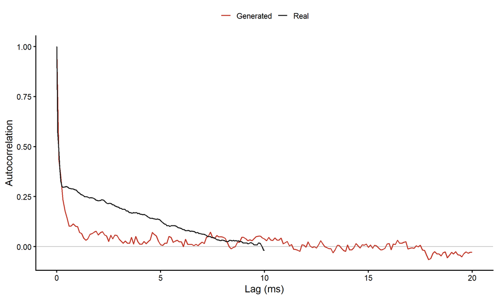

```r
acf_of <- function(x, lag_max, fs) {
  a <- stats::acf(x - mean(x), lag.max = lag_max, plot = FALSE, demean = TRUE)
  tibble::tibble(lag_ms = 1000 * a$lag[, 1, 1] / fs, acf = a$acf[, 1, 1])
}

acf_df <- dplyr::bind_rows(
  dplyr::mutate(acf_of(closed_real_seg, CFG$acf_lag_max, FS_REAL), source = "Real"),
  dplyr::mutate(acf_of(closed_gen_seg,  CFG$acf_lag_max, FS_GEN),  source = "Generated")
)

p_acf <- ggplot(acf_df, aes(lag_ms, acf, colour = source)) +
  geom_hline(yintercept = 0, colour = "grey70", linewidth = 0.3) +
  geom_line(linewidth = 0.5) +
  scale_colour_manual(values = pal_source) +
  labs(x = "Lag (ms)", y = "Autocorrelation") +
  theme_channel()

p_acf
```

```r
save_fig(p_acf, "fig3B_autocorrelation")

# Compare on lag index rather than lag time, so a rate mismatch does not
# silently drop every row when the two lag grids fail to line up.
acf_wide <- acf_df |>
  dplyr::group_by(source) |>
  dplyr::mutate(lag_n = dplyr::row_number()) |>
  dplyr::ungroup() |>
  dplyr::select(lag_n, source, acf) |>
  tidyr::pivot_wider(names_from = source, values_from = acf) |>
  tidyr::drop_na()
acf_rmse <- sqrt(mean((acf_wide$Real - acf_wide$Generated)^2))

record_value("acf_rmse", round(acf_rmse, 4), "RMS difference in ACF")
record_value("acf_description",
  sprintf("ACF curves differ by an RMS of %.3f over the first %.1f ms of lag.",
          acf_rmse, 1000 * CFG$acf_lag_max / FS_REAL),
  "REPLACE with your own reading of Figure 3B")

p_noise <- p_psd + p_acf + patchwork::plot_annotation(tag_levels = "A")
save_fig(p_noise, "fig3_noise", width = 10, height = 4)
```

# 5. Figure 4: the slow envelope

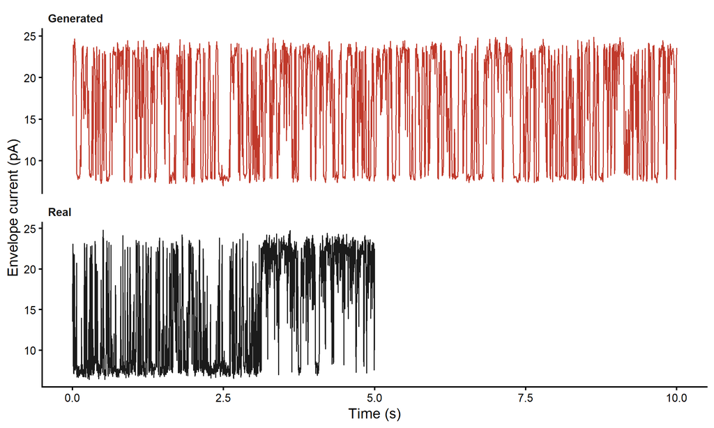

```r
env_real <- block_mean(real$current, CFG$slow_factor)
env_gen  <- block_mean(gen$current,  CFG$slow_factor)

env_len <- min(length(env_real), length(env_gen))
env_df  <- dplyr::bind_rows(
  tibble::tibble(idx = seq_len(env_len), value = env_real[seq_len(env_len)],
                 source = "Real"),
  tibble::tibble(idx = seq_len(env_len), value = env_gen[seq_len(env_len)],
                 source = "Generated")
)

if (has_single) {
  env_single <- block_mean(gen_single$current, CFG$slow_factor)
  el <- min(env_len, length(env_single))
  env_df <- dplyr::bind_rows(
    env_df,
    tibble::tibble(idx = seq_len(el), value = env_single[seq_len(el)],
                   source = "Single-stage")
  )
}

env_fs <- c("Real" = FS_REAL, "Generated" = FS_GEN, "Single-stage" = FS_SING)
env_df <- dplyr::mutate(env_df,
  time_s = idx * CFG$slow_factor / unname(env_fs[source]))

p_env <- ggplot(env_df, aes(time_s, value, colour = source)) +
  geom_line(linewidth = 0.4) +
  facet_wrap(~ source, ncol = 1, scales = "free_y") +
  scale_colour_manual(values = pal_source, guide = "none") +
  labs(x = "Time (s)", y = "Envelope current (pA)") +
  theme_channel()

p_env
```

```r
save_fig(p_env, "fig4A_envelope", height = 5)

p_env_dist <- ggplot(env_df, aes(value, colour = source, fill = source)) +
  geom_density(alpha = 0.18, linewidth = 0.5) +
  scale_colour_manual(values = pal_source) +
  scale_fill_manual(values = pal_source) +
  labs(x = "Envelope current (pA)", y = "Density") +
  theme_channel()

save_fig(p_env_dist, "fig4C_envelope_distribution")

record_value("env_sd_real",     round(sd(env_real), 4))
record_value("env_sd_cascade",  round(sd(env_gen), 4))

We_r <- make_windows(env_real, min(64, length(env_real)), CFG$n_windows_mmd)
We_g <- make_windows(env_gen,  min(64, length(env_gen)),  CFG$n_windows_mmd)
record_value("mmd_env_cascade", signif(mmd_rbf(We_r, We_g), 4))

if (has_single) {
  record_value("env_sd_single", round(sd(env_single), 4))
  We_s <- make_windows(env_single, min(64, length(env_single)), CFG$n_windows_mmd)
  record_value("mmd_env_single", signif(mmd_rbf(We_r, We_s), 4))
} else {
  record_value("env_sd_single",  "NOT RUN", "no single-stage ablation available")
  record_value("mmd_env_single", "NOT RUN", "no single-stage ablation available")
}
```

# 6. Figure 5: block joins

If the context-carry inpainting works, the distribution of sample-to-sample differences in the neighbourhood of a block boundary should be indistinguishable from that within blocks. If it does not work, you will see it here before a reviewer does.

```
##
##  Asymptotic two-sample Kolmogorov-Smirnov test
##
## data:  a and b
## D = 0.02038, p-value = 0.555
## alternative hypothesis: two-sided
```

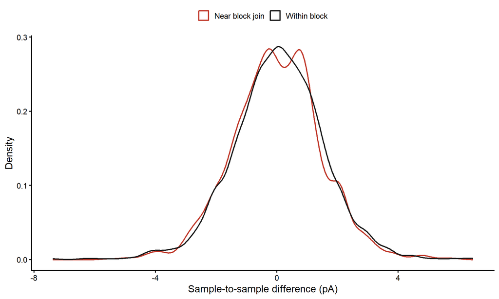

```r
step <- CFG$block_len - CFG$context_len
boundaries <- seq(step, nrow(gen) - 1, by = step)
boundaries <- boundaries[boundaries > CFG$context_len &
                         boundaries < (nrow(gen) - CFG$context_len)]

diffs <- diff(gen$current)

if (length(boundaries)) {
  near_idx <- unique(unlist(lapply(boundaries, function(b)
    seq(b - CFG$context_len %/% 2, b + CFG$context_len %/% 2))))
  near_idx <- near_idx[near_idx >= 1 & near_idx <= length(diffs)]
  far_idx  <- setdiff(seq_along(diffs), near_idx)

  ks_seam <- ks_safe(diffs[near_idx], diffs[far_idx])
  record_value("ks_seam", round(unname(ks_seam$statistic), 4),
               "KS statistic, sample differences near vs away from block joins")
  print(ks_seam)

  seam_df <- dplyr::bind_rows(
    tibble::tibble(d = diffs[near_idx], where = "Near block join"),
    tibble::tibble(d = diffs[sample(far_idx, min(length(far_idx),
                                                 length(near_idx)))],
                   where = "Within block")
  )

  p_seam <- ggplot(seam_df, aes(d, colour = where)) +
    geom_density(linewidth = 0.6, adjust = 0.8) +
    scale_colour_manual(values = c("Near block join" = "#c0392b",
                                   "Within block"    = "#1b1b1b")) +
    labs(x = "Sample-to-sample difference (pA)", y = "Density") +
    theme_channel()
  print(p_seam)
  save_fig(p_seam, "fig5B_seam_test")
} else {
  message("Generated record spans a single block; no joins to test.")
  record_value("ks_seam", "N/A", "single block, no joins")
}
```

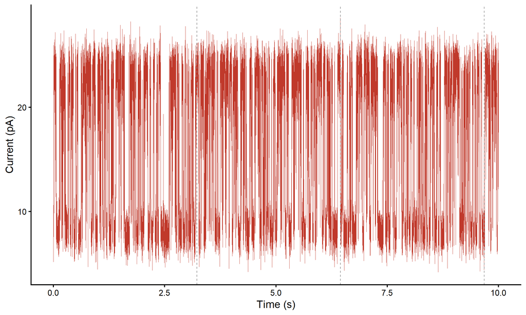

```r
# The long trace itself, with boundaries marked.
decim <- max(1L, nrow(gen) %/% 20000L)
long_df <- gen[seq(1, nrow(gen), by = decim), ]

p_long <- ggplot(long_df, aes(time, current)) +
  geom_line(linewidth = 0.15, colour = pal_source[["Generated"]]) +
  { if (length(boundaries))
      geom_vline(xintercept = gen$time[boundaries], linetype = "dashed",
                 colour = "grey55", linewidth = 0.3) } +
  labs(x = "Time (s)", y = "Current (pA)") +
  theme_channel()

p_long
```

```r
save_fig(p_long, "fig5A_long_record", height = 3)
```

# 7. Figure 6: dwell times and the ground-truth check

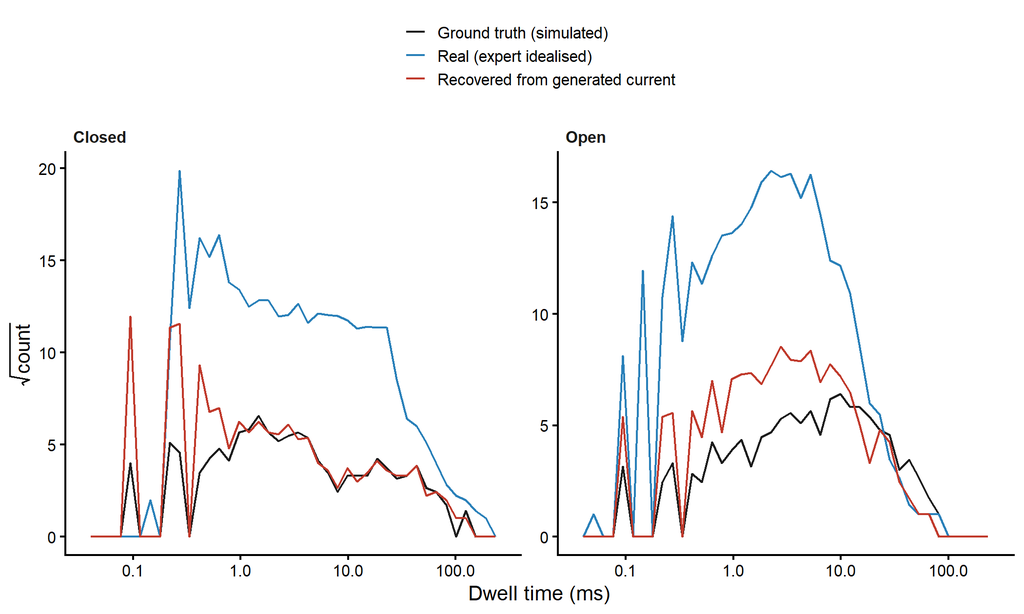

```r
dw_truth <- dwell_times(gen$channels, FS_GEN) |>
  dplyr::mutate(origin = "Ground truth (simulated)")

n_lev <- max(gen$channels, na.rm = TRUE)
ideal_recovered <- idealise_half_amplitude(gen$current, n_levels = max(1, n_lev))

if (all(is.na(ideal_recovered))) {
  stop("The half-amplitude idealiser failed on the generated trace. ",
       "Read the baseline and open level off Figure 2E and pass them in:\n",
       "  idealise_half_amplitude(gen$current, unit_pA = <open - baseline>, ",
       "baseline = <closed level>, n_levels = max(1, n_lev))")
}
if (length(rle(ideal_recovered)$lengths) > 0.5 * length(ideal_recovered)) {
  warning("The recovered idealisation switches on almost every sample, which ",
          "means the level estimate is wrong rather than that the record is ",
          "fast. Check unit_pA before believing anything in Figure 6C-D.")
}

dw_recov <- dwell_times(ideal_recovered, FS_GEN) |>
  dplyr::mutate(origin = "Recovered from generated current")

dw_real <- dwell_times(real$channels, FS_REAL) |>
  dplyr::mutate(origin = "Real (expert idealised)")

dw_all <- dplyr::bind_rows(dw_truth, dw_recov, dw_real) |>
  dplyr::filter(dwell_ms > 0)

# Sigworth-Sine display: log abscissa, square-root ordinate.
p_dwell <- ggplot(dw_all, aes(dwell_ms, colour = origin)) +
  geom_freqpoly(aes(y = after_stat(sqrt(count))), bins = 40, linewidth = 0.55) +
  scale_x_log10(labels = scales::label_number()) +
  facet_wrap(~ state, scales = "free_y") +
  scale_colour_manual(values = c(
    "Ground truth (simulated)"         = "#1b1b1b",
    "Recovered from generated current" = "#c0392b",
    "Real (expert idealised)"          = "#2980b9")) +
  labs(x = "Dwell time (ms)", y = expression(sqrt(count))) +
  theme_channel() +
  theme(legend.position = "top", legend.direction = "vertical")

p_dwell
```

```r
save_fig(p_dwell, "fig6_dwell_times", width = 8, height = 4.6)

dwell_summary <- dw_all |>
  dplyr::group_by(origin, state) |>
  dplyr::summarise(
    n         = dplyr::n(),
    mean_ms   = mean(dwell_ms),
    median_ms = median(dwell_ms),
    .groups   = "drop"
  )

knitr::kable(dwell_summary, digits = 3,
             caption = "Dwell-time summary by origin and state.")
```

Dwell-time summary by origin and state.

| origin | state | n | mean_ms | median_ms |
| --- | --- | --- | --- | --- |
| Ground truth (simulated) | Closed | 546 | 8.176 | 2.00 |
| Ground truth (simulated) | Open | 546 | 10.139 | 5.85 |
| Real (expert idealised) | Closed | 4171 | 6.268 | 1.55 |
| Real (expert idealised) | Open | 4171 | 3.610 | 2.00 |
| Recovered from generated current | Closed | 1033 | 4.438 | 0.50 |
| Recovered from generated current | Open | 1033 | 5.242 | 2.80 |

```r
readr::write_csv(dwell_summary, file.path(CFG$out_dir, "dwell_summary.csv"))

get_mean <- function(df, o, s) {
  v <- df |> dplyr::filter(origin == o, state == s) |> dplyr::pull(mean_ms)
  if (length(v)) round(v[1], 3) else NA_real_
}

record_value("tau_open_true",       get_mean(dwell_summary, "Ground truth (simulated)", "Open"))
record_value("tau_closed_true",     get_mean(dwell_summary, "Ground truth (simulated)", "Closed"))
record_value("tau_open_recovered",  get_mean(dwell_summary, "Recovered from generated current", "Open"))
record_value("tau_closed_recovered", get_mean(dwell_summary, "Recovered from generated current", "Closed"))
```

Note that `mean_ms` is a mean dwell time, not a fitted exponential time constant. If you want the time constants quoted in the manuscript to be fitted rather than empirical, fit a mixture of exponentials to `dw_all` and substitute those. The empirical mean is a defensible summary and is what the placeholders currently carry.

# 8. Figure 7: manifold projections

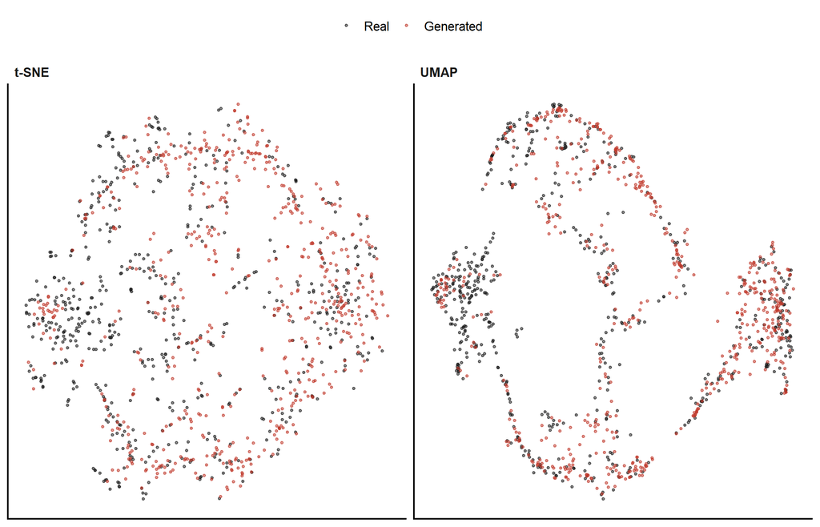

```r
Wp_real <- make_windows(real$current, CFG$proj_win, CFG$n_windows_proj)
Wp_gen  <- make_windows(gen$current,  CFG$proj_win, CFG$n_windows_proj)

X   <- rbind(Wp_real, Wp_gen)
lab <- rep(c("Real", "Generated"), c(nrow(Wp_real), nrow(Wp_gen)))

# Robust scaling before projection, as in the DeepGANnel pipeline.
X <- scale(X, center = TRUE, scale = TRUE)
X[!is.finite(X)] <- 0

um <- uwot::umap(X, n_neighbors = 15, min_dist = 0.1, n_components = 2)
ts <- Rtsne::Rtsne(X, dims = 2, perplexity = 30, check_duplicates = FALSE,
                   pca = TRUE, verbose = FALSE)$Y

proj_df <- dplyr::bind_rows(
  tibble::tibble(x = um[, 1], y = um[, 2], source = lab, method = "UMAP"),
  tibble::tibble(x = ts[, 1], y = ts[, 2], source = lab, method = "t-SNE")
) |>
  dplyr::mutate(source = factor(source, levels = c("Real", "Generated")))

p_proj <- ggplot(proj_df, aes(x, y, colour = source)) +
  geom_point(size = 0.6, alpha = 0.55) +
  facet_wrap(~ method, scales = "free") +
  scale_colour_manual(values = pal_source) +
  labs(x = NULL, y = NULL) +
  theme_channel() +
  theme(axis.text = element_blank(), axis.ticks = element_blank())

p_proj
```

```r
save_fig(p_proj, "fig7_manifold", width = 8, height = 4.2)

readr::write_csv(proj_df, file.path(CFG$out_dir, "manifold_coordinates.csv"))
```

Cluster separation testing with `ClusterSignificance` (as in DeepGANnel) is not run here because the package is a Bioconductor dependency that many installations lack. If you have it, the projection coordinates have been written to `manifold_coordinates.csv` and can be fed to `ClusterSignificance::Pcp()` directly. Record the resulting p value against the `cluster_p` placeholder.

```r
record_value("cluster_p", "TO BE FILLED",
             "run ClusterSignificance on manifold_coordinates.csv")
record_value("manifold_description", "REPLACE with your reading of Figure 7",
             "describe the degree of overlap you actually see")
```

# 9. Table 3: collected similarity metrics

```r
table3 <- tibble::tibble(
  Metric = c(
    "MMD, real vs generated",
    "MMD, real vs real (split half)",
    "MMD, real vs white noise",
    "KS statistic, amplitude distribution",
    "Closed-state SD, real (pA)",
    "Closed-state SD, generated (pA)",
    "Log10 PSD RMS difference",
    "ACF RMS difference",
    "Envelope SD, real (pA)",
    "Envelope SD, generated (pA)"
  ),
  Value = c(
    signif(mmd_main, 4), signif(mmd_within_real, 4), signif(mmd_white, 4),
    round(unname(ks_amp$statistic), 4),
    round(sd(closed_real), 4), round(sd(closed_gen), 4),
    round(psd_rmse, 3), round(acf_rmse, 4),
    round(sd(env_real), 4), round(sd(env_gen), 4)
  )
)

knitr::kable(table3, caption = "Table 3. Similarity metrics.")
```

Table 3. Similarity metrics.

| Metric | Value |
| --- | --- |
| MMD, real vs generated | 0.045880 |
| MMD, real vs real (split half) | 0.004824 |
| MMD, real vs white noise | 0.072120 |
| KS statistic, amplitude distribution | 0.185700 |
| Closed-state SD, real (pA) | 1.579000 |
| Closed-state SD, generated (pA) | 1.675500 |
| Log10 PSD RMS difference | 0.397000 |
| ACF RMS difference | 0.132500 |
| Envelope SD, real (pA) | 6.166400 |
| Envelope SD, generated (pA) | 6.502000 |

```r
readr::write_csv(table3, file.path(CFG$out_dir, "table3_metrics.csv"))
```

# 10. Write the placeholder values

```r
results_tbl <- dplyr::bind_rows(RESULTS$rows) |> dplyr::arrange(placeholder)

readr::write_csv(results_tbl, file.path(CFG$out_dir, "results_values.csv"))

knitr::kable(results_tbl,
             caption = "Values keyed to the [[placeholders]] in the manuscript draft.")
```

Values keyed to the [[placeholders]] in the manuscript draft.

| placeholder | value | note |
| --- | --- | --- |
| acf_description | ACF curves differ by an RMS of 0.132 over the first 10.0 ms of lag. | REPLACE with your own reading of Figure 3B |
| acf_rmse | 0.1325 | RMS difference in ACF |
| block_len | 32768 |  |
| burst_tc | 1000 | flicker threshold for the burst clock |
| cluster_p | TO BE FILLED | run ClusterSignificance on manifold_coordinates.csv |
| context_len | 512 |  |
| emb_dim | 4 |  |
| emb_drop | 0.1 |  |
| env_sd_cascade | 6.502 |  |
| env_sd_real | 6.166 |  |
| env_sd_single | NOT RUN | no single-stage ablation available |
| filter_khz | 1 |  |
| ks_D | 0.1857 | KS statistic, all-points amplitude, real vs generated |
| ks_seam | 0.0204 | KS statistic, sample differences near vs away from block joins |
| long_len_s | 10 |  |
| manifold_description | REPLACE with your reading of Figure 7 | describe the degree of overlap you actually see |
| mmd_env_cascade | 0.07015 |  |
| mmd_env_single | NOT RUN | no single-stage ablation available |
| mmd_gamma | 7.025e-05 | median-heuristic kernel bandwidth |
| mmd_main | 0.04588 |  |
| mmd_perm_p | 0.00498 | permutation p, real vs generated windows |
| mmd_white | 0.07212 |  |
| mmd_within_real | 0.004824 |  |
| modes_gen | 8.11 | modal current, generated, pA |
| modes_real | 8.23 | modal current, real, pA |
| n_blocks | 4 |  |
| n_records | 1 | seed records |
| n_samples | 824,001 | total seed samples |
| n_seconds | 41.2 | seconds of seed data |
| psd_description | Real and generated spectra agree to an RMS difference of 0.40 log10 units below the 1000 Hz filter corner. | REPLACE with your own reading of Figure 3A |
| psd_log_rmse | 0.397 | RMS difference in log10 PSD below filter corner |
| sample_khz | 20 |  |
| sd_gen | 1.675 | closed-state SD, generated, pA |
| sd_real | 1.579 | closed-state SD, real, pA |
| seq_len | 128 |  |
| seq_len_ms | 6.4 | training window duration |
| slow_factor | 64 |  |
| tau_closed_recovered | 4.438 |  |
| tau_closed_true | 8.176 |  |
| tau_open_recovered | 5.242 |  |
| tau_open_true | 10.14 |  |

```r
cat("\nWritten to", file.path(CFG$out_dir, "results_values.csv"), "\n")
```

```
##
## Written to ./figures/results_values.csv
```

```r
cat("Any row reading TO BE FILLED, NOT RUN or REPLACE needs your attention",
    "before the manuscript goes anywhere.\n")
```

```
## Any row reading TO BE FILLED, NOT RUN or REPLACE needs your attention before the manuscript goes anywhere.
```